# ExtraaLearn Project

## Context

The EdTech industry has been surging in the past decade immensely, and according to a forecast, the Online Education market would be worth $286.62bn by 2023 with a compound annual growth rate (CAGR) of 10.26% from 2018 to 2023. The modern era of online education has enforced a lot in its growth and expansion beyond any limit. Due to having many dominant features like ease of information sharing, personalized learning experience, transparency of assessment, etc, it is now preferable to traditional education.

In the present scenario due to the Covid-19, the online education sector has witnessed rapid growth and is attracting a lot of new customers. Due to this rapid growth, many new companies have emerged in this industry. With the availability and ease of use of digital marketing resources, companies can reach out to a wider audience with their offerings. The customers who show interest in these offerings are termed as leads. There are various sources of obtaining leads for Edtech companies, like

- The customer interacts with the marketing front on social media or other online platforms.
- The customer browses the website/app and downloads the brochure
- The customer connects through emails for more information.

The company then nurtures these leads and tries to convert them to paid customers. For this, the representative from the organization connects with the lead on call or through email to share further details.

## Objective

ExtraaLearn is an initial stage startup that offers programs on cutting-edge technologies to students and professionals to help them upskill/reskill. With a large number of leads being generated on a regular basis, one of the issues faced by ExtraaLearn is to identify which of the leads are more likely to convert so that they can allocate resources accordingly. You, as a data scientist at ExtraaLearn, have been provided the leads data to:

- Analyze and build an ML model to help identify which leads are more likely to convert to paid customers,
- Find the factors driving the lead conversion process
- Create a profile of the leads which are likely to convert

## Data Description

The data contains the different attributes of leads and their interaction details with ExtraaLearn. The detailed data dictionary is given below.

**Data Dictionary**

- ID: ID of the lead
- age: Age of the lead
- current_occupation: Current occupation of the lead. Values include 'Professional','Unemployed',and 'Student'
- first_interaction: How did the lead first interacted with ExtraaLearn. Values include 'Website', 'Mobile App'
- profile_completed: What percentage of profile has been filled by the lead on the website/mobile app. Values include Low - (0-50%), Medium - (50-75%), High (75-100%)
- website_visits: How many times has a lead visited the website
- time_spent_on_website: Total time spent on the website
- page_views_per_visit: Average number of pages on the website viewed during the visits.
- last_activity: Last interaction between the lead and ExtraaLearn.
  - Email Activity: Seeking for details about program through email, Representative shared information with lead like brochure of program , etc
  - Phone Activity: Had a Phone Conversation with representative, Had conversation over SMS with representative, etc
  - Website Activity: Interacted on live chat with representative, Updated profile on website, etc
- print_media_type1: Flag indicating whether the lead had seen the ad of ExtraaLearn in the Newspaper.
- print_media_type2: Flag indicating whether the lead had seen the ad of ExtraaLearn in the Magazine.
- digital_media: Flag indicating whether the lead had seen the ad of ExtraaLearn on the digital platforms.
- educational_channels: Flag indicating whether the lead had heard about ExtraaLearn in the education channels like online forums, discussion threads, educational websites, etc.
- referral: Flag indicating whether the lead had heard about ExtraaLearn through reference.
- status: Flag indicating whether the lead was converted to a paid customer or not.

## 1) Importing necessary libraries and data

```python
import pandas as pd
import numpy as np

# Library to split data
from sklearn.model_selection import train_test_split

# libaries to help with data visualization
import matplotlib.pyplot as plt
import seaborn as sns

# To build model for prediction
import statsmodels.stats.api as sms
from statsmodels.stats.outliers_influence import variance_inflation_factor
import statsmodels.api as sm
from statsmodels.tools.tools import add_constant
from sklearn.linear_model import LogisticRegression
from sklearn.tree import DecisionTreeClassifier
from sklearn import tree
from sklearn.ensemble import RandomForestClassifier

# To tune different models
from sklearn.model_selection import GridSearchCV

# To get diferent metric scores
import sklearn.metrics as metrics
from sklearn.metrics import (
    f1_score,
    accuracy_score,
    recall_score,
    precision_score,
    confusion_matrix,
    classification_report,
    roc_auc_score,
    precision_recall_curve,
    roc_curve,
    make_scorer,
)

import warnings

warnings.filterwarnings("ignore")
from statsmodels.tools.sm_exceptions import ConvergenceWarning

warnings.simplefilter("ignore", ConvergenceWarning)
```

```python
from IPython.core.interactiveshell import InteractiveShell
InteractiveShell.ast_node_interactivity = "all"
```

```python
df = pd.read_csv('C:/Users/argop/OneDrive/Desktop/Python/GL Assignments/Extra learners/ExtraaLearn.csv')
# returns the first 5 rows
df.head()
```

|  | ID | age | current_occupation | first_interaction | profile_completed | website_visits | time_spent_on_website | page_views_per_visit | last_activity | print_media_type1 | print_media_type2 | digital_media | educational_channels | referral | status |
| --- | --- | --- | --- | --- | --- | --- | --- | --- | --- | --- | --- | --- | --- | --- | --- |
| 0 | EXT001 | 57 | Unemployed | Website | High | 7 | 1639 | 1.861 | Website Activity | Yes | No | Yes | No | No | 1 |
| 1 | EXT002 | 56 | Professional | Mobile App | Medium | 2 | 83 | 0.320 | Website Activity | No | No | No | Yes | No | 0 |
| 2 | EXT003 | 52 | Professional | Website | Medium | 3 | 330 | 0.074 | Website Activity | No | No | Yes | No | No | 0 |
| 3 | EXT004 | 53 | Unemployed | Website | High | 4 | 464 | 2.057 | Website Activity | No | No | No | No | No | 1 |
| 4 | EXT005 | 23 | Student | Website | High | 4 | 600 | 16.914 | Email Activity | No | No | No | No | No | 0 |

```python
# Rows
print("number of rows : ", df.shape[0])

# Columns
print("number of columns : ", df.shape[1])
```

```
number of rows :  4612
number of columns :  15
```

```python
#Checking the columns in the dataset
print(df.info())
```

```
<class 'pandas.core.frame.DataFrame'>
RangeIndex: 4612 entries, 0 to 4611
Data columns (total 15 columns):
 #   Column                 Non-Null Count  Dtype
---  ------                 --------------  -----
 0   ID                     4612 non-null   object
 1   age                    4612 non-null   int64
 2   current_occupation     4612 non-null   object
 3   first_interaction      4612 non-null   object
 4   profile_completed      4612 non-null   object
 5   website_visits         4612 non-null   int64
 6   time_spent_on_website  4612 non-null   int64
 7   page_views_per_visit   4612 non-null   float64
 8   last_activity          4612 non-null   object
 9   print_media_type1      4612 non-null   object
 10  print_media_type2      4612 non-null   object
 11  digital_media          4612 non-null   object
 12  educational_channels   4612 non-null   object
 13  referral               4612 non-null   object
 14  status                 4612 non-null   int64
dtypes: float64(1), int64(4), object(10)
memory usage: 540.6+ KB
None
```

#### No NaN missing values in any column in the dataset

## 2) Data Overview

- Observations
- Sanity checks

```python
print("Count total NaN at each column in a DataFrame: \n ", df.isnull().sum())
print("No missing values in any column in the data")
```

```
Count total NaN at each column in a DataFrame:
  ID                       0
age                      0
current_occupation       0
first_interaction        0
profile_completed        0
website_visits           0
time_spent_on_website    0
page_views_per_visit     0
last_activity            0
print_media_type1        0
print_media_type2        0
digital_media            0
educational_channels     0
referral                 0
status                   0
dtype: int64
No missing values in any column in the data
```

```python
duplicate = df[df.duplicated()]

print("Duplicate Rows :")

# Print the resultant Dataframe
duplicate
```

```
Duplicate Rows :
```

|  | ID | age | current_occupation | first_interaction | profile_completed | website_visits | time_spent_on_website | page_views_per_visit | last_activity | print_media_type1 | print_media_type2 | digital_media | educational_channels | referral | status |
| --- | --- | --- | --- | --- | --- | --- | --- | --- | --- | --- | --- | --- | --- | --- | --- |

```python
df['ID'].nunique()
```

```
4612
```

#### No duplicate enrties in the dataset

### Data overview Findings:

1) There are no duplicates in entire row or in the Lead identifier (ID) variables 2) There no missing variables in any column

## 3) Univariate analysis:

```python
df[['age', 'website_visits', 'time_spent_on_website', 'page_views_per_visit','status']].describe().applymap('{:,.1f}'.format).T
```

|  | count | mean | std | min | 25% | 50% | 75% | max |
| --- | --- | --- | --- | --- | --- | --- | --- | --- |
| age | 4,612.0 | 46.2 | 13.2 | 18.0 | 36.0 | 51.0 | 57.0 | 63.0 |
| website_visits | 4,612.0 | 3.6 | 2.8 | 0.0 | 2.0 | 3.0 | 5.0 | 30.0 |
| time_spent_on_website | 4,612.0 | 724.0 | 743.8 | 0.0 | 148.8 | 376.0 | 1,336.8 | 2,537.0 |
| page_views_per_visit | 4,612.0 | 3.0 | 2.0 | 0.0 | 2.1 | 2.8 | 3.8 | 18.4 |
| status | 4,612.0 | 0.3 | 0.5 | 0.0 | 0.0 | 0.0 | 1.0 | 1.0 |

```python
columns=['current_occupation','first_interaction','profile_completed','last_activity','print_media_type1','print_media_type2','digital_media','educational_channels','referral','status']

for col in columns:
    print("-----------Column is:",col,"---------------")
    pd.set_option('display.float_format', '{:.1%}'.format)
    display(df[col].value_counts(normalize=True))
```

```
-----------Column is: current_occupation ---------------
```

```
Professional   56.7%
Unemployed     31.2%
Student        12.0%
Name: current_occupation, dtype: float64
```

```
-----------Column is: first_interaction ---------------
```

```
Website      55.1%
Mobile App   44.9%
Name: first_interaction, dtype: float64
```

```
-----------Column is: profile_completed ---------------
```

```
High     49.1%
Medium   48.6%
Low       2.3%
Name: profile_completed, dtype: float64
```

```
-----------Column is: last_activity ---------------
```

```
Email Activity     49.4%
Phone Activity     26.8%
Website Activity   23.9%
Name: last_activity, dtype: float64
```

```
-----------Column is: print_media_type1 ---------------
```

```
No    89.2%
Yes   10.8%
Name: print_media_type1, dtype: float64
```

```
-----------Column is: print_media_type2 ---------------
```

```
No    94.9%
Yes    5.1%
Name: print_media_type2, dtype: float64
```

```
-----------Column is: digital_media ---------------
```

```
No    88.6%
Yes   11.4%
Name: digital_media, dtype: float64
```

```
-----------Column is: educational_channels ---------------
```

```
No    84.7%
Yes   15.3%
Name: educational_channels, dtype: float64
```

```
-----------Column is: referral ---------------
```

```
No    98.0%
Yes    2.0%
Name: referral, dtype: float64
```

```
-----------Column is: status ---------------
```

```
0   70.1%
1   29.9%
Name: status, dtype: float64
```

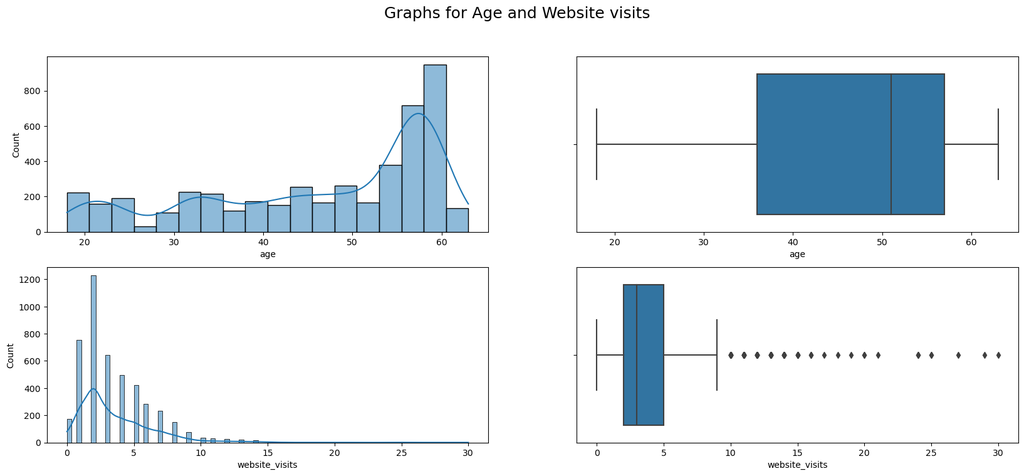

```python
#Histogram and Boxplot for the numerical variables - Age and Website visits
fig, axes = plt.subplots(2, 2, figsize = (20, 8))
fig.suptitle('Graphs for Age and Website visits', fontsize = 18)

sns.histplot(x = 'age', data = df, kde = True, ax = axes[0,0]);
sns.boxplot(x = 'age', data = df, ax = axes[0,1])

sns.histplot(x = 'website_visits', data = df, kde = True, ax = axes[1,0]);
sns.boxplot(x = 'website_visits', data = df, ax = axes[1,1])
```

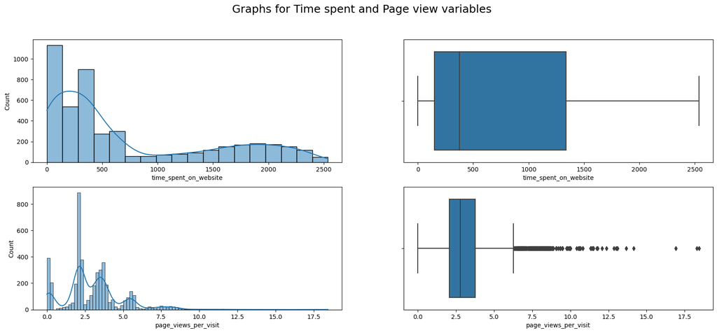

```python
#Histogram and Boxplot for the numerical variables - Time spend on Website and Page views per visit
fig, axes = plt.subplots(2, 2, figsize = (20, 8))
fig.suptitle('Graphs for Time spent and Page view variables', fontsize = 18)

sns.histplot(x = 'time_spent_on_website', data = df, kde = True, ax = axes[0,0]);
sns.boxplot(x = 'time_spent_on_website', data = df, ax = axes[0,1])

sns.histplot(x = 'page_views_per_visit', data = df, kde = True, ax = axes[1,0]);
sns.boxplot(x = 'page_views_per_visit', data = df, ax = axes[1,1])
```

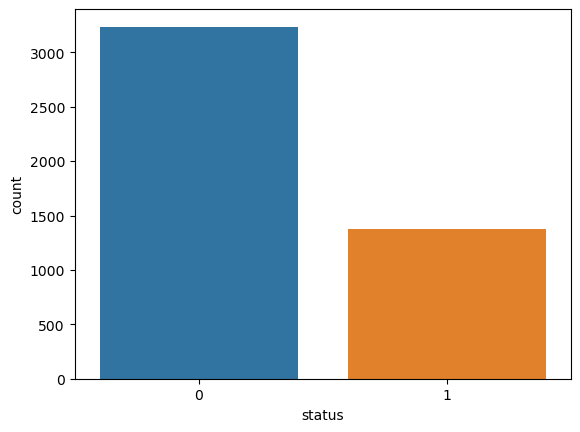

```python
#Distribution of the even variables values - 0 and 1
figsize=(10,5)
fig.suptitle('Bar plot of the Status variable', fontsize = 18)
sns.countplot(x = 'status', data = df, order = df['status'].value_counts(normalize=True).index)
```

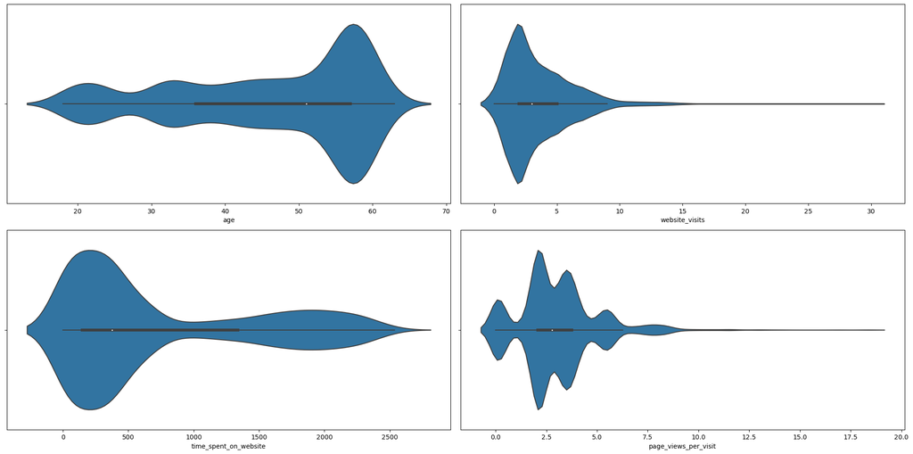

```python
#Violin plot for the numerical variables
num_vars = ['age', 'website_visits', 'time_spent_on_website', 'page_views_per_visit']

fig, axs = plt.subplots(nrows=2, ncols=2, figsize=(20, 10))
axs = axs.flatten()

for i, var in enumerate(num_vars):
    sns.violinplot(x=var, data=df, ax=axs[i])

fig.tight_layout()

plt.show()
```

```python
#The trend of the numerical variables by the event (status) values

def chart_func(variable,status,data):
    fig, axes = plt.subplots(1, 3, figsize = (15, 6))
    fig.suptitle("Distribution by the variable: " + str.title(variable))
    axes[0].set_title("Distribution for status=1")
    sns.histplot(x = variable, data = df[df['status']==1], kde = True, ax = axes[0]);
    axes[1].set_title("Distribution for status=0")
    sns.histplot(x = variable, data = df[df['status']==0], kde = True, ax = axes[1]);
    axes[2].set_title("Boxplot by status values")
    sns.boxplot(x=status, y = variable, data = df, ax = axes[2]);
```

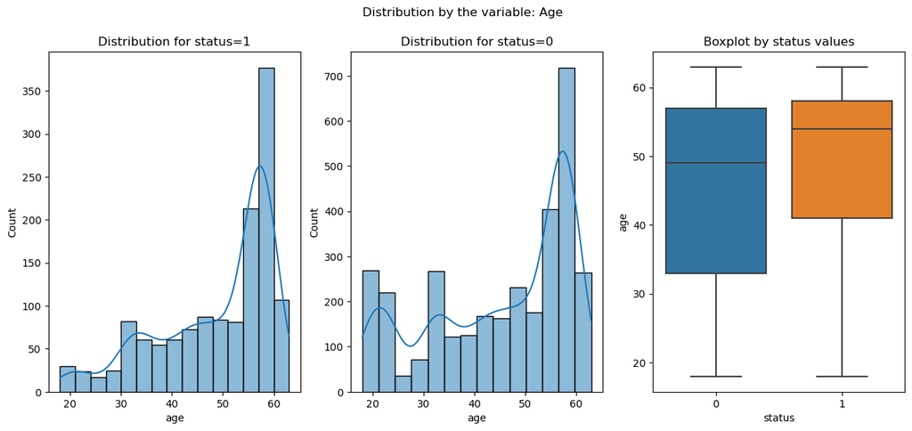

```python
chart_func('age','status',df)
```

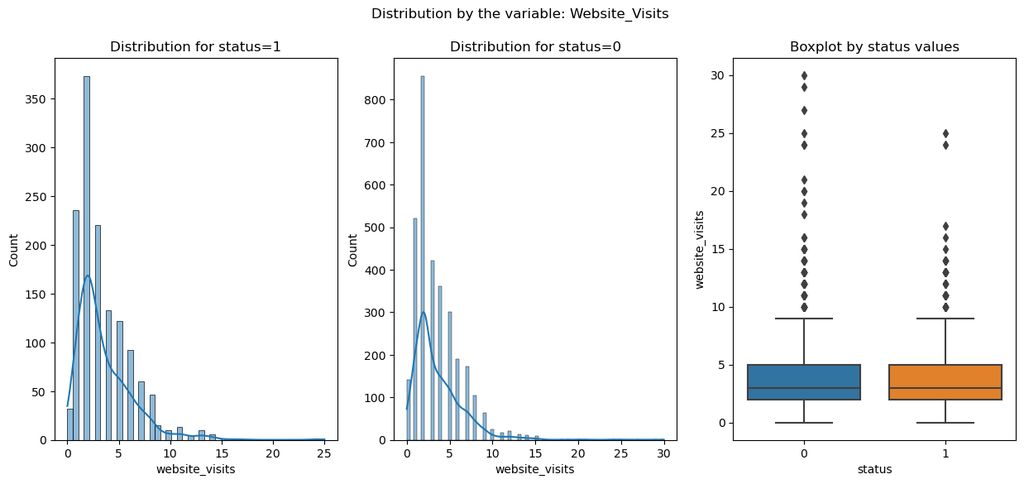

```python
chart_func('website_visits','status',df)
```

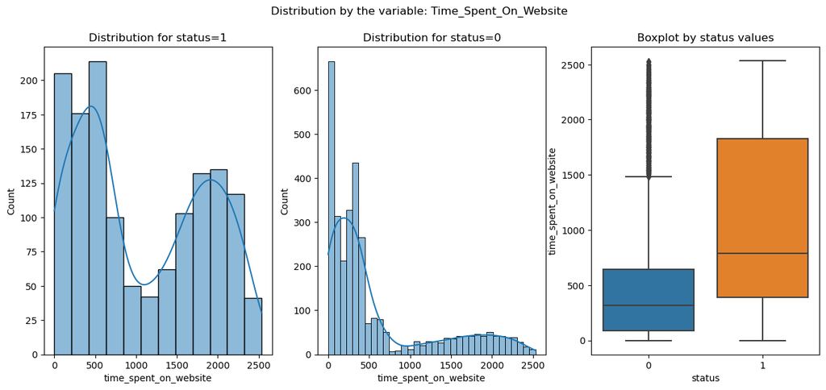

```python
chart_func('time_spent_on_website','status',df)
```

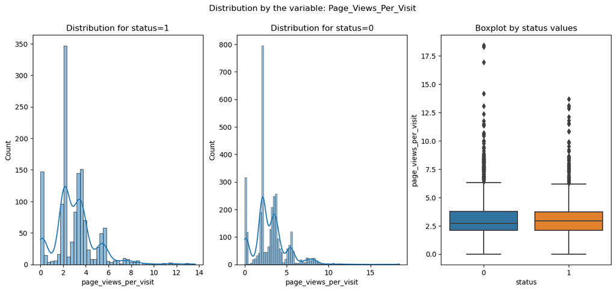

```python
chart_func('page_views_per_visit','status',df)
```

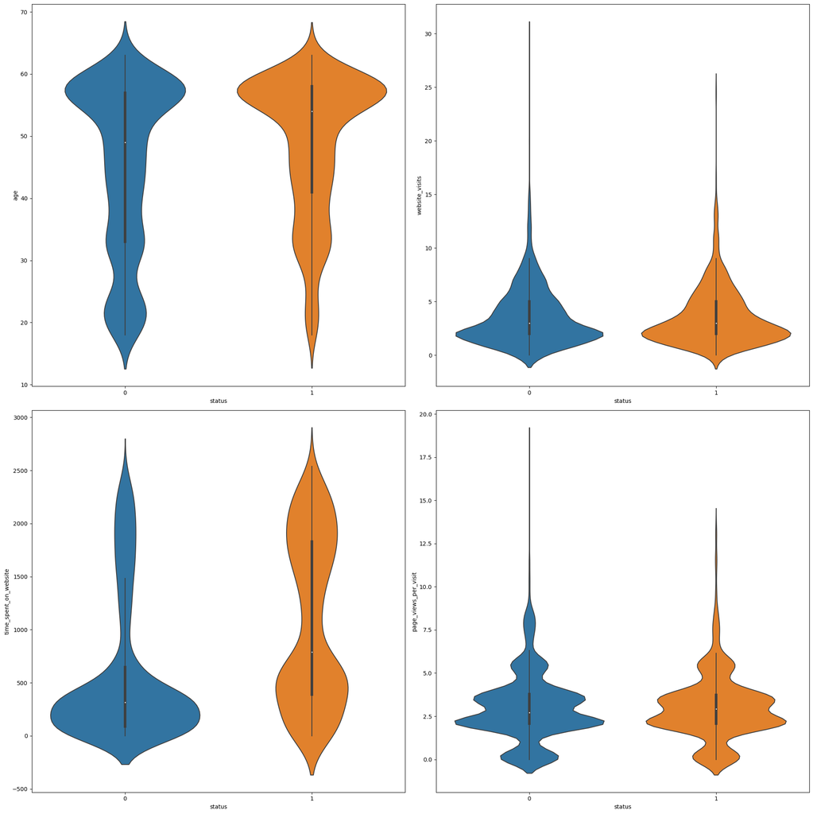

```python
#Violin plot for the numerical variables - split by the event variable values
num_vars = ['age', 'website_visits', 'time_spent_on_website', 'page_views_per_visit']

fig, axs = plt.subplots(nrows=2, ncols=2, figsize=(20, 20))
axs = axs.flatten()

for i, var in enumerate(num_vars):

    sns.violinplot(y=var, data=df, x='status', ax=axs[i])
    #axs[i].set_title("Distribution for ",num_vars)

fig.tight_layout()

plt.show()
```

### Variable distribution Findings:

1) 56% of the leads are professionals and there is an even mix of the leads from the first interaction sources: Website and App traffic 2) ~50% of the leads' last activity is email 3) Very few (2%) of the leads are from referrals. The referral network isn't very wide spread for the Ed Tech 4) ~30% of the leads convert, which is a good response rate. Also, the dataset doesnt seem imbalanced because of the 30% event rate 5) The mean age and mean time spent on the website is higher for the converted leads than the non-converted leads 6) Outliers: It seems the Page views per visit, Time spent on the website (especially for Status=0) and Website visits have outliers. Will look into this in the later section for any treatment

## 4) Exploratory Data Analysis (EDA)

- EDA is an important part of any project involving data.
- It is important to investigate and understand the data better before building a model with it.
- A few questions have been mentioned below which will help you approach the analysis in the right manner and generate insights from the data.
- A thorough analysis of the data, in addition to the questions mentioned below, should be done.

**Questions**

1. Leads will have different expectations from the outcome of the course and the current occupation may play a key role in getting them to participate in the program. Find out how current occupation affects lead status.
2. The company's first impression on the customer must have an impact. Do the first channels of interaction have an impact on the lead status?
3. The company uses multiple modes to interact with prospects. Which way of interaction works best?
4. The company gets leads from various channels such as print media, digital media, referrals, etc. Which of these channels have the highest lead conversion rate?
5. People browsing the website or mobile application are generally required to create a profile by sharing their personal data before they can access additional information.Does having more details about a prospect increase the chances of conversion?

```python
#Reviewing the conversion rate (Paid customers / Total customers) by the class variables
EDA_columns=['current_occupation','first_interaction','profile_completed','last_activity','print_media_type1','print_media_type2','digital_media','educational_channels','referral']

for col in EDA_columns:
    piv=df.pivot_table(index = [col], columns='status', values=['ID'],aggfunc= 'count', margins = True, margins_name='Total')
    piv.columns = ['_'.join(str(s).strip() for s in col if s) for col in piv.columns]
    piv.reset_index(inplace=True)
    piv=piv.rename(columns={'ID':'Not_Paid_Cust',
                       'ID_1':'Paid_Cust',
                       'ID_Total':'Total'})
    piv['Conversion_rate in %']=round(piv['Paid_Cust']/piv['Total']*100,1)

    piv
```

|  | current_occupation | Not_Paid_Cust | Paid_Cust | Total | Conversion_rate in % |
| --- | --- | --- | --- | --- | --- |
| 0 | Professional | 1687 | 929 | 2616 | 3550.0% |
| 1 | Student | 490 | 65 | 555 | 1170.0% |
| 2 | Unemployed | 1058 | 383 | 1441 | 2660.0% |
| 3 | Total | 3235 | 1377 | 4612 | 2990.0% |

|  | first_interaction | Not_Paid_Cust | Paid_Cust | Total | Conversion_rate in % |
| --- | --- | --- | --- | --- | --- |
| 0 | Mobile App | 1852 | 218 | 2070 | 1050.0% |
| 1 | Website | 1383 | 1159 | 2542 | 4560.0% |
| 2 | Total | 3235 | 1377 | 4612 | 2990.0% |

|  | profile_completed | Not_Paid_Cust | Paid_Cust | Total | Conversion_rate in % |
| --- | --- | --- | --- | --- | --- |
| 0 | High | 1318 | 946 | 2264 | 4180.0% |
| 1 | Low | 99 | 8 | 107 | 750.0% |
| 2 | Medium | 1818 | 423 | 2241 | 1890.0% |
| 3 | Total | 3235 | 1377 | 4612 | 2990.0% |

|  | last_activity | Not_Paid_Cust | Paid_Cust | Total | Conversion_rate in % |
| --- | --- | --- | --- | --- | --- |
| 0 | Email Activity | 1587 | 691 | 2278 | 3030.0% |
| 1 | Phone Activity | 971 | 263 | 1234 | 2130.0% |
| 2 | Website Activity | 677 | 423 | 1100 | 3850.0% |
| 3 | Total | 3235 | 1377 | 4612 | 2990.0% |

|  | print_media_type1 | Not_Paid_Cust | Paid_Cust | Total | Conversion_rate in % |
| --- | --- | --- | --- | --- | --- |
| 0 | No | 2897 | 1218 | 4115 | 2960.0% |
| 1 | Yes | 338 | 159 | 497 | 3200.0% |
| 2 | Total | 3235 | 1377 | 4612 | 2990.0% |

|  | print_media_type2 | Not_Paid_Cust | Paid_Cust | Total | Conversion_rate in % |
| --- | --- | --- | --- | --- | --- |
| 0 | No | 3077 | 1302 | 4379 | 2970.0% |
| 1 | Yes | 158 | 75 | 233 | 3220.0% |
| 2 | Total | 3235 | 1377 | 4612 | 2990.0% |

|  | digital_media | Not_Paid_Cust | Paid_Cust | Total | Conversion_rate in % |
| --- | --- | --- | --- | --- | --- |
| 0 | No | 2876 | 1209 | 4085 | 2960.0% |
| 1 | Yes | 359 | 168 | 527 | 3190.0% |
| 2 | Total | 3235 | 1377 | 4612 | 2990.0% |

|  | educational_channels | Not_Paid_Cust | Paid_Cust | Total | Conversion_rate in % |
| --- | --- | --- | --- | --- | --- |
| 0 | No | 2727 | 1180 | 3907 | 3020.0% |
| 1 | Yes | 508 | 197 | 705 | 2790.0% |
| 2 | Total | 3235 | 1377 | 4612 | 2990.0% |

|  | referral | Not_Paid_Cust | Paid_Cust | Total | Conversion_rate in % |
| --- | --- | --- | --- | --- | --- |
| 0 | No | 3205 | 1314 | 4519 | 2910.0% |
| 1 | Yes | 30 | 63 | 93 | 6770.0% |
| 2 | Total | 3235 | 1377 | 4612 | 2990.0% |

```
The correlation heatmap for the numerical variables:
```

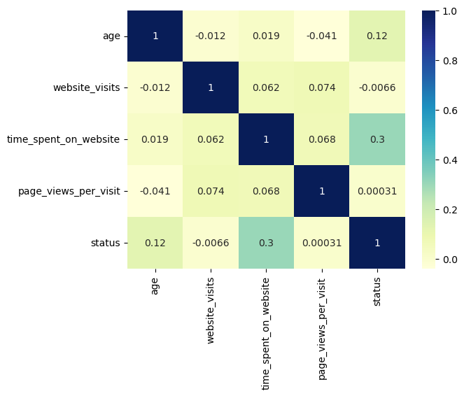

```python
#Correlation Heatmap
num_cols=['age', 'website_visits', 'time_spent_on_website', 'page_views_per_visit','status']

dataplot = sns.heatmap(df[num_cols].corr(), cmap="YlGnBu", annot=True)
print("The correlation heatmap for the numerical variables:")
# displaying heatmap
plt.show()
```

### Findings on EDA:

1) Conversion rate is much higher for Professionals than Unemployed and Students and is higher than the average total conversion rate 2) Conversion rate is significantly higher for the leads who had their first interaction from website compared to mobile. Similarly, conversion rate is higher for the leads who had their last activity through website (chatted with representative, completed profile on website), followed by email and phone activity (phone conversation or SMS with representative) 3) Conversion rate rank orders by the profile completeness. Leads who had high profile completeness have significantly higher conversion rate 4) Conversion rate isn't very different between the leads who came via ads on newspaper, magazine, digital, education channels vs. leads who didn't come from these channels 5) Even though only 2% leads came via referral source, the conversion rate for these leads is drastically different compared to leads who didn't come via referral. Referral network thus is working very well in terms of conversion rate and the Ed Tech firm needs to focus on expanding referral program 6) No significant correlation among the numerical variables

## 5) Outlier detection and treatment

[output not shown]

[output not shown]

[output not shown]

[output not shown]

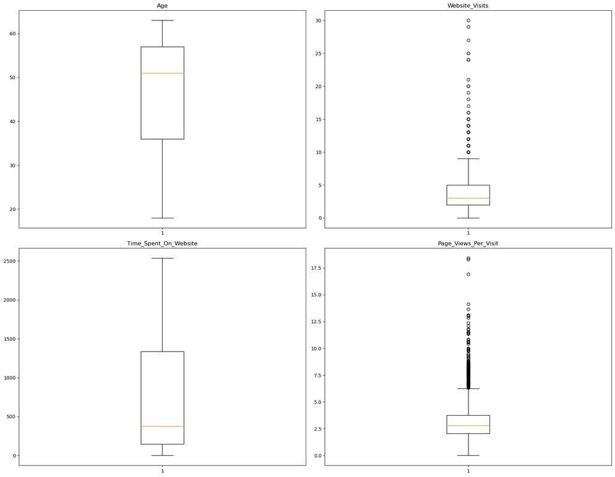

```python
# Outlier detection using boxplot
Cols_for_Outlier=['age', 'website_visits', 'time_spent_on_website', 'page_views_per_visit']

plt.figure(figsize=(18, 14))

for i, col in enumerate(Cols_for_Outlier):
    plt.subplot(2, 2, i+1)
    plt.boxplot(df[col], whis=1.5)
    plt.tight_layout()
    plt.title(str.title(col))

plt.show()
```

```python
#Outlier Treatment: Page_Views_Per_Visit variable using Boxplot (points above Q3 + IQR are treated)
PV_q1 = np.quantile(df['page_views_per_visit'], 0.25)
PV_q3 = np.quantile(df['page_views_per_visit'], 0.75)
PV_iqr = PV_q3-PV_q1

PV_upper_bound = PV_q3+(1.5*PV_iqr)
PV_lower_bound = PV_q1-(1.5*PV_iqr)
print(PV_iqr, PV_upper_bound, PV_lower_bound)
```

```
1.6784999999999997 6.273999999999999 -0.4399999999999995
```

```python
df['page_views_per_visit_2'] = np.where(df["page_views_per_visit"] > PV_upper_bound, PV_upper_bound, df["page_views_per_visit"])
df.head()
```

|  | ID | age | current_occupation | first_interaction | profile_completed | website_visits | time_spent_on_website | page_views_per_visit | last_activity | print_media_type1 | print_media_type2 | digital_media | educational_channels | referral | status | page_views_per_visit_2 |
| --- | --- | --- | --- | --- | --- | --- | --- | --- | --- | --- | --- | --- | --- | --- | --- | --- |
| 0 | EXT001 | 57 | Unemployed | Website | High | 7 | 1639 | 186.1% | Website Activity | Yes | No | Yes | No | No | 1 | 186.1% |
| 1 | EXT002 | 56 | Professional | Mobile App | Medium | 2 | 83 | 32.0% | Website Activity | No | No | No | Yes | No | 0 | 32.0% |
| 2 | EXT003 | 52 | Professional | Website | Medium | 3 | 330 | 7.4% | Website Activity | No | No | Yes | No | No | 0 | 7.4% |
| 3 | EXT004 | 53 | Unemployed | Website | High | 4 | 464 | 205.7% | Website Activity | No | No | No | No | No | 1 | 205.7% |
| 4 | EXT005 | 23 | Student | Website | High | 4 | 600 | 1691.4% | Email Activity | No | No | No | No | No | 0 | 627.4% |

```
Boxplot after removing outliers from Page_views_per_visit variable
```

```
{'whiskers': [<matplotlib.lines.Line2D at 0x212470cebf0>,
 'caps': [<matplotlib.lines.Line2D at 0x21247181e10>,
 'boxes': [<matplotlib.lines.Line2D at 0x212470cca30>],
 'medians': [<matplotlib.lines.Line2D at 0x2124775a620>],
 'fliers': [<matplotlib.lines.Line2D at 0x21247060190>],
 'means': []}
```

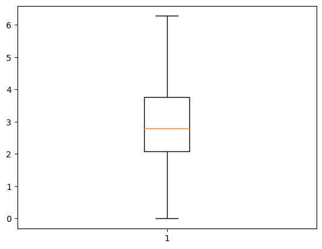

```python
print("Boxplot after removing outliers from Page_views_per_visit variable")
plt.boxplot(df['page_views_per_visit_2'], whis=1.5)
```

```python
print("Comapring original page_views_per_visit variable and the new variable after removing outliers")
df[['page_views_per_visit','page_views_per_visit_2']].describe().applymap('{:,.1f}'.format).T
```

```
Comapring original page_views_per_visit variable and the new variable after removing outliers
```

|  | count | mean | std | min | 25% | 50% | 75% | max |
| --- | --- | --- | --- | --- | --- | --- | --- | --- |
| page_views_per_visit | 4,612.0 | 3.0 | 2.0 | 0.0 | 2.1 | 2.8 | 3.8 | 18.4 |
| page_views_per_visit_2 | 4,612.0 | 2.9 | 1.7 | 0.0 | 2.1 | 2.8 | 3.8 | 6.3 |

```python
#Outlier Treatment: Website_visits variable using Boxplot (points above Q3 + IQR are treated)
WV_q1 = np.quantile(df['website_visits'], 0.25)
WV_q3 = np.quantile(df['website_visits'], 0.75)
WV_iqr=WV_q3-WV_q1

WV_upper_bound = WV_q3+(1.5*WV_iqr)
WV_lower_bound = WV_q1-(1.5*WV_iqr)
print(WV_iqr, WV_upper_bound, WV_lower_bound)
```

```
3.0 9.5 -2.5
```

```python
df['website_visits_2'] = np.where(df["website_visits"] > WV_upper_bound, WV_upper_bound, df["website_visits"])
df.head()
```

|  | ID | age | current_occupation | first_interaction | profile_completed | website_visits | time_spent_on_website | page_views_per_visit | last_activity | print_media_type1 | print_media_type2 | digital_media | educational_channels | referral | status | page_views_per_visit_2 | website_visits_2 |
| --- | --- | --- | --- | --- | --- | --- | --- | --- | --- | --- | --- | --- | --- | --- | --- | --- | --- |
| 0 | EXT001 | 57 | Unemployed | Website | High | 7 | 1639 | 186.1% | Website Activity | Yes | No | Yes | No | No | 1 | 186.1% | 700.0% |
| 1 | EXT002 | 56 | Professional | Mobile App | Medium | 2 | 83 | 32.0% | Website Activity | No | No | No | Yes | No | 0 | 32.0% | 200.0% |
| 2 | EXT003 | 52 | Professional | Website | Medium | 3 | 330 | 7.4% | Website Activity | No | No | Yes | No | No | 0 | 7.4% | 300.0% |
| 3 | EXT004 | 53 | Unemployed | Website | High | 4 | 464 | 205.7% | Website Activity | No | No | No | No | No | 1 | 205.7% | 400.0% |
| 4 | EXT005 | 23 | Student | Website | High | 4 | 600 | 1691.4% | Email Activity | No | No | No | No | No | 0 | 627.4% | 400.0% |

```
Boxplot after removing outliers from Website visit variable
```

```
{'whiskers': [<matplotlib.lines.Line2D at 0x212447950f0>,
 'caps': [<matplotlib.lines.Line2D at 0x212449a8d60>,
 'boxes': [<matplotlib.lines.Line2D at 0x2124471ef80>],
 'medians': [<matplotlib.lines.Line2D at 0x212449aa020>],
 'fliers': [<matplotlib.lines.Line2D at 0x212449aa470>],
 'means': []}
```

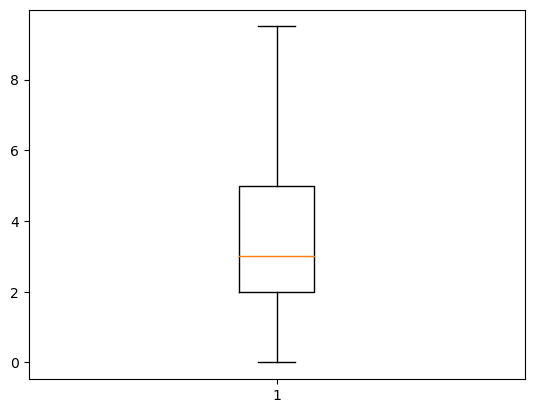

```python
print("Boxplot after removing outliers from Website visit variable")
plt.boxplot(df['website_visits_2'], whis=1.5)
```

```python
print("Comapring original website_visit variable and the new variable after removing outliers")
df[['website_visits','website_visits_2']].describe().applymap('{:,.1f}'.format).T
```

```
Comapring original website_visit variable and the new variable after removing outliers
```

|  | count | mean | std | min | 25% | 50% | 75% | max |
| --- | --- | --- | --- | --- | --- | --- | --- | --- |
| website_visits | 4,612.0 | 3.6 | 2.8 | 0.0 | 2.0 | 3.0 | 5.0 | 30.0 |
| website_visits_2 | 4,612.0 | 3.4 | 2.4 | 0.0 | 2.0 | 3.0 | 5.0 | 9.5 |

## 6) Data Preprocessing

- Feature engineering (if needed)
- Preparing data for modeling

```python
X = df.drop(['status','ID','website_visits','page_views_per_visit'], axis=1)
Y = df['status']
X.head()
```

|  | age | current_occupation | first_interaction | profile_completed | time_spent_on_website | last_activity | print_media_type1 | print_media_type2 | digital_media | educational_channels | referral | page_views_per_visit_2 | website_visits_2 |
| --- | --- | --- | --- | --- | --- | --- | --- | --- | --- | --- | --- | --- | --- |
| 0 | 57 | Unemployed | Website | High | 1639 | Website Activity | Yes | No | Yes | No | No | 186.1% | 700.0% |
| 1 | 56 | Professional | Mobile App | Medium | 83 | Website Activity | No | No | No | Yes | No | 32.0% | 200.0% |
| 2 | 52 | Professional | Website | Medium | 330 | Website Activity | No | No | Yes | No | No | 7.4% | 300.0% |
| 3 | 53 | Unemployed | Website | High | 464 | Website Activity | No | No | No | No | No | 205.7% | 400.0% |
| 4 | 23 | Student | Website | High | 600 | Email Activity | No | No | No | No | No | 627.4% | 400.0% |

```python
X = pd.get_dummies(X, drop_first = True)
X.head()
```

|  | age | time_spent_on_website | page_views_per_visit_2 | website_visits_2 | current_occupation_Student | current_occupation_Unemployed | first_interaction_Website | profile_completed_Low | profile_completed_Medium | last_activity_Phone Activity | last_activity_Website Activity | print_media_type1_Yes | print_media_type2_Yes | digital_media_Yes | educational_channels_Yes | referral_Yes |
| --- | --- | --- | --- | --- | --- | --- | --- | --- | --- | --- | --- | --- | --- | --- | --- | --- |
| 0 | 57 | 1639 | 186.1% | 700.0% | 0 | 1 | 1 | 0 | 0 | 0 | 1 | 1 | 0 | 1 | 0 | 0 |
| 1 | 56 | 83 | 32.0% | 200.0% | 0 | 0 | 0 | 0 | 1 | 0 | 1 | 0 | 0 | 0 | 1 | 0 |
| 2 | 52 | 330 | 7.4% | 300.0% | 0 | 0 | 1 | 0 | 1 | 0 | 1 | 0 | 0 | 1 | 0 | 0 |
| 3 | 53 | 464 | 205.7% | 400.0% | 0 | 1 | 1 | 0 | 0 | 0 | 1 | 0 | 0 | 0 | 0 | 0 |
| 4 | 23 | 600 | 627.4% | 400.0% | 1 | 0 | 1 | 0 | 0 | 0 | 0 | 0 | 0 | 0 | 0 | 0 |

```python
# Splitting the data in 70:30 ratio for train to test data
X_train, X_test, y_train, y_test = train_test_split(X, Y, test_size=0.30, random_state=42, stratify = Y)
```

```python
print("Shape of Training set : ", X_train.shape)
print("Shape of test set : ", X_test.shape)
print("Percentage of event variable in training set:")
print(y_train.value_counts(normalize=True))
print("Percentage of event variable in test set:")
print(y_test.value_counts(normalize=True))
```

```
Shape of Training set :  (3228, 16)
Shape of test set :  (1384, 16)
Percentage of event variable in training set:
0   70.1%
1   29.9%
Name: status, dtype: float64
Percentage of event variable in test set:
0   70.2%
1   29.8%
Name: status, dtype: float64
```

#### The % of events (converted customers) is similar in both Train and Test datasets. Also, the sampling is done through stratified sampling to ensure similar trend of the event variable across the class/categorical variables in the dataset

## EDA

- It is a good idea to explore the data once again after manipulating it. - Already done in the Outlier treatment section

## 7) Building a Decision Tree model

### 7.1 Decision Tree model first iteration

```python
from sklearn.tree import DecisionTreeClassifier
dtree = DecisionTreeClassifier(random_state=42, max_depth=3, min_samples_leaf=1, min_samples_split=2, class_weight='balanced')
dtree.fit(X_train, y_train)
```

```
DecisionTreeClassifier(class_weight='balanced', max_depth=3, random_state=42)
```

```python
#Precdicting the tuned Decision Tree on the Train dataset
y_pred_train1 =dtree.predict(X_train)
```

```python
from sklearn.metrics import accuracy_score
#Precdicting the tuned Decision Tree on the Test dataset
y_pred = dtree.predict(X_test)
print("Accuracy Score in Train dataset using Decision Tree First iteration model:", round(accuracy_score(y_pred_train1, y_train)*100 ,2), "%")
print("Accuracy Score in Test dataset using Decision Tree First iteration model:", round(accuracy_score(y_test, y_pred)*100 ,2), "%")
```

```
Accuracy Score in Train dataset using Decision Tree First iteration model: 78.97 %
Accuracy Score in Test dataset using Decision Tree First iteration model: 78.9 %
```

#### We can assess the Accuracy score in this case since the data isn't imbalanced as ~30% of the data has the event of conversion. Had the data been imbalanced, Accuracy shouldn't have been considered for reviewing model performance. However, as explained above, it's not the case with this dataset and hence we can look at Accuracy score for model performance evaluation

```python
from sklearn.metrics import accuracy_score, f1_score, precision_score, recall_score
print("In the Train dataset using Decision Tree First iteration model:\n")
print('F-1 Score : ',(f1_score(y_train, y_pred_train1, average='micro')))
print('Precision Score : ',(precision_score(y_train, y_pred_train1, average='micro')))
print('Recall Score : ',(recall_score(y_train, y_pred_train1, average='micro')))
print('AUC : ',metrics.roc_auc_score(y_train, y_pred_train1))

print("\n\n")
print("In the Test dataset using Decision Tree First iteration model:\n")
print('F-1 Score : ',(f1_score(y_test, y_pred, average='micro')))
print('Precision Score : ',(precision_score(y_test, y_pred, average='micro')))
print('Recall Score : ',(recall_score(y_test, y_pred, average='micro')))
print('AUC : ',metrics.roc_auc_score(y_test, y_pred))
```

```
In the Train dataset using Decision Tree First iteration model:

F-1 Score :  0.7896530359355638
Precision Score :  0.7896530359355638
Recall Score :  0.7896530359355638
AUC :  0.8217508760611703



In the Test dataset using Decision Tree First iteration model:

F-1 Score :  0.7890173410404624
Precision Score :  0.7890173410404624
Recall Score :  0.7890173410404624
AUC :  0.8211149983916135
```

#### In this business case, Recall is more important than Precision because the cost of False Negative events is higher. The Ed Tech missing potential customers who could have converted is more detrimental than targeting few False positive customers. Hence, we should focus more on Recall in this model. However, Recall and Precision values are quite similar in this model

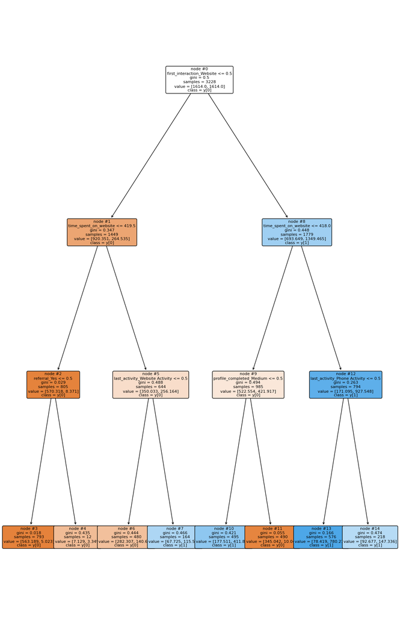

```python
features = list(X.columns)
from sklearn.tree import plot_tree

plt.subplots(figsize=(14,22))
plot_tree(dtree,
         feature_names=features,
         rounded=True,
         filled=True,
         fontsize = 8, node_ids = True, class_names = True);
```

[figure not shown]

```python
imp_df = pd.DataFrame({
    "Feature Name": X_train.columns,
    "Importance": dtree.feature_importances_
})
fi = imp_df.sort_values(by="Importance", ascending=False)

fi2 = fi.head(6)
plt.figure(figsize=(10,8))
sns.barplot(data=fi2, x='Importance', y='Feature Name')
plt.title('Top 10 Feature Importance Each Attributes (Decision Tree)', fontsize=10)
plt.xlabel ('Importance', fontsize=9)
plt.ylabel ('Feature Name', fontsize=9)
plt.show()
```

```python
pip install shap
```

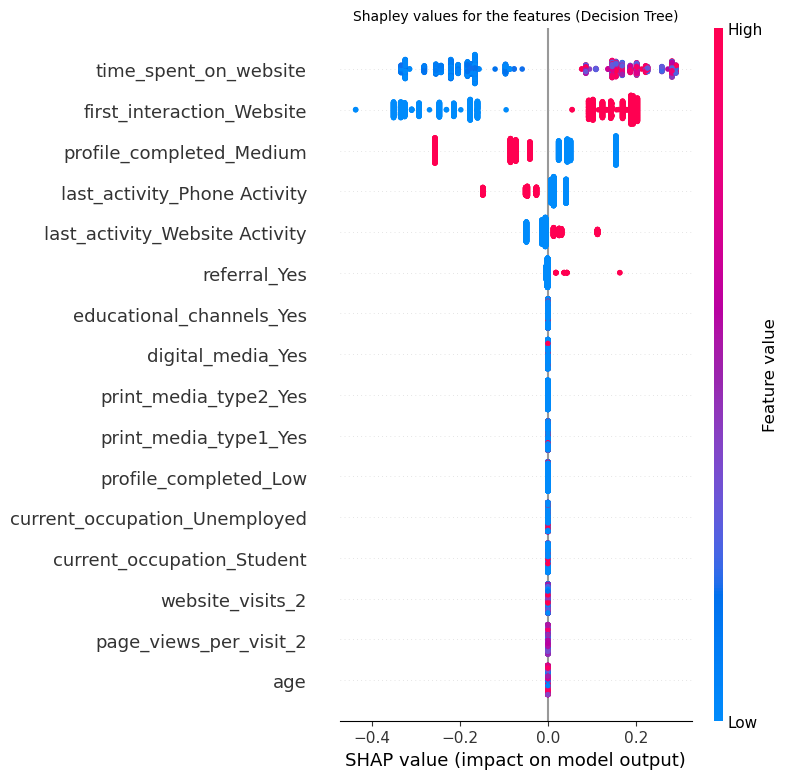

```python
import shap
plt.title('Shapley values for the features (Decision Tree)', fontsize=10)
explainer = shap.TreeExplainer(dtree)
shap_values = explainer.shap_values(X_test)
shap.summary_plot(shap_values[1], X_test)
#shap.plots.beeswarm(shap_values,X_test)
```

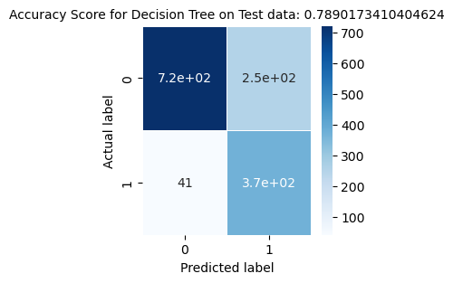

```python
#Confusion matrix on Test data
from sklearn.metrics import confusion_matrix
cm = confusion_matrix(y_test, y_pred)
plt.figure(figsize=(3,3))
sns.heatmap(data=cm,linewidths=.5, annot=True,  cmap = 'Blues')
plt.ylabel('Actual label')
plt.xlabel('Predicted label')
all_sample_title = 'Accuracy Score for Decision Tree on Test data: {0}'.format(dtree.score(X_test, y_test))
plt.title(all_sample_title, size = 10)
```

### 7.2 Pruning the tree: Decision Tree model Grid Search algorithm

#### The initial Decision Tree model performance doesn't deteriorate in the Test data compared to the Train data by reviewing AUC, Precision and Recall values. This indicates the Decision Tree model with the initial hyperparameters is not prone to overfitting . However, its prudent to optimize the hyperparaterms using Grid Search to assess if the model performance can be further improved

```python
from sklearn.tree import DecisionTreeClassifier
from sklearn.model_selection import GridSearchCV
dtree = DecisionTreeClassifier(class_weight='balanced')
param_grid = {
    'max_depth': [3, 4, 5, 6, 7, 8],
    'min_samples_split': [2, 3, 4],
    'min_samples_leaf': [1, 2, 3, 4],
    'random_state': [0, 10, 15, 42]
}

# Perform a grid search with cross-validation to find the best hyperparameters
grid_search = GridSearchCV(dtree, param_grid, cv=5)
grid_search.fit(X_train, y_train)

# Print the best hyperparameters
print(grid_search.best_params_)
```

```
GridSearchCV(cv=5, estimator=DecisionTreeClassifier(class_weight='balanced'),
             param_grid={'max_depth': [3, 4, 5, 6, 7, 8],
                         'min_samples_leaf': [1, 2, 3, 4],
                         'min_samples_split': [2, 3, 4],
                         'random_state': [0, 10, 15, 42]})
```

```
{'max_depth': 5, 'min_samples_leaf': 1, 'min_samples_split': 2, 'random_state': 0}
```

```python
from sklearn.tree import DecisionTreeClassifier
dtree_tuned = DecisionTreeClassifier(random_state=0, max_depth=5, min_samples_leaf=1, min_samples_split=2, class_weight='balanced')
dtree_tuned.fit(X_train, y_train)
```

```
DecisionTreeClassifier(class_weight='balanced', max_depth=5, random_state=0)
```

```python
#Precdicting the tuned Decision Tree on the Train dataset
y_pred_train1_tuned =dtree_tuned.predict(X_train)

#Precdicting the tuned Decision Tree on the Test dataset
y_pred_test_tuned = dtree_tuned.predict(X_test)
```

```python
from sklearn.metrics import accuracy_score, f1_score, precision_score, recall_score
print("In the Train dataset using Decision Tree Grid search optimized model:\n")
print('F-1 Score : ',(f1_score(y_train, y_pred_train1_tuned, average='micro')))
print('Precision Score : ',(precision_score(y_train, y_pred_train1_tuned, average='micro')))
print('Recall Score : ',(recall_score(y_train, y_pred_train1_tuned, average='micro')))
print('AUC : ',metrics.roc_auc_score(y_train, y_pred_train1_tuned))

print("\n\n")
print("In the Test dataset using Decision Tree Grid search optimized model:\n")
print('F-1 Score : ',(f1_score(y_test, y_pred_test_tuned, average='micro')))
print('Precision Score : ',(precision_score(y_test, y_pred_test_tuned, average='micro')))
print('Recall Score : ',(recall_score(y_test, y_pred_test_tuned, average='micro')))
print('AUC : ',metrics.roc_auc_score(y_test, y_pred_test_tuned))
```

```
In the Train dataset using Decision Tree Grid search optimized model:

F-1 Score :  0.8435563816604709
Precision Score :  0.8435563816604709
Recall Score :  0.8435563816604709
AUC :  0.8551154274738648



In the Test dataset using Decision Tree Grid search optimized model:

F-1 Score :  0.8388728323699421
Precision Score :  0.8388728323699421
Recall Score :  0.8388728323699421
AUC :  0.8482967311101857
```

#### The evalution metrics improve in the Grid search optimized Decision tree compared to the initial iteration of Decision Tree model in both Training and Test datasets. No overfitting happening

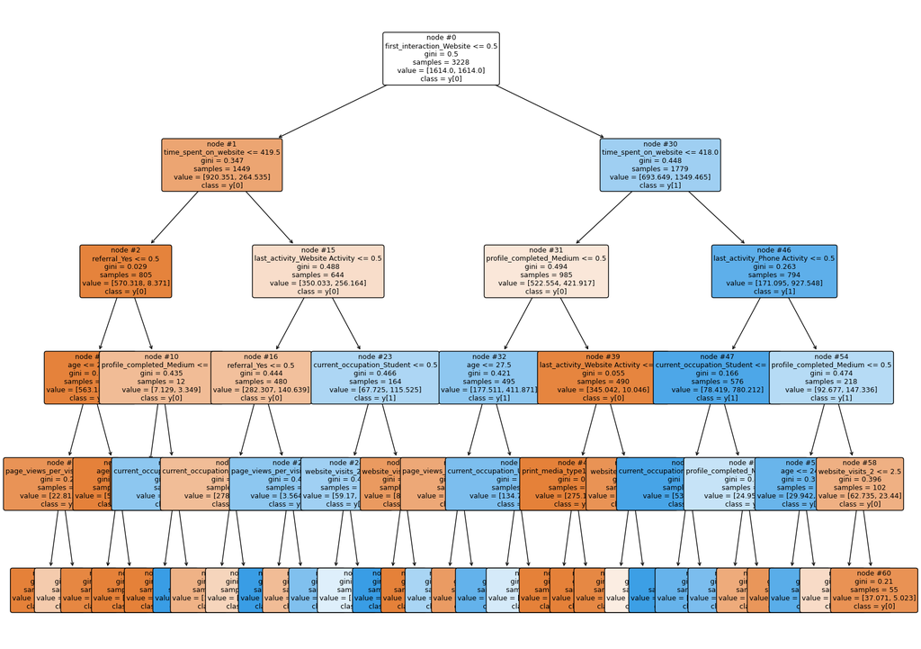

```python
features = list(X.columns)
from sklearn.tree import plot_tree

plt.subplots(figsize=(20,15))
plot_tree(dtree_tuned,
         feature_names=features,
         rounded=True,
         filled=True,
         fontsize = 9, node_ids = True, class_names = True);
```

[figure not shown]

```python
imp_df = pd.DataFrame({
    "Feature Name": X_train.columns,
    "Importance": dtree_tuned.feature_importances_
})
fi = imp_df.sort_values(by="Importance", ascending=False)

fi2 = fi.head(6)
plt.figure(figsize=(10,8))
sns.barplot(data=fi2, x='Importance', y='Feature Name')
plt.title('Top 10 Feature Importance Each Attributes (Decision Tree Grid searched optimized model)', fontsize=10)
plt.xlabel ('Importance', fontsize=9)
plt.ylabel ('Feature Name', fontsize=9)
plt.show()
```

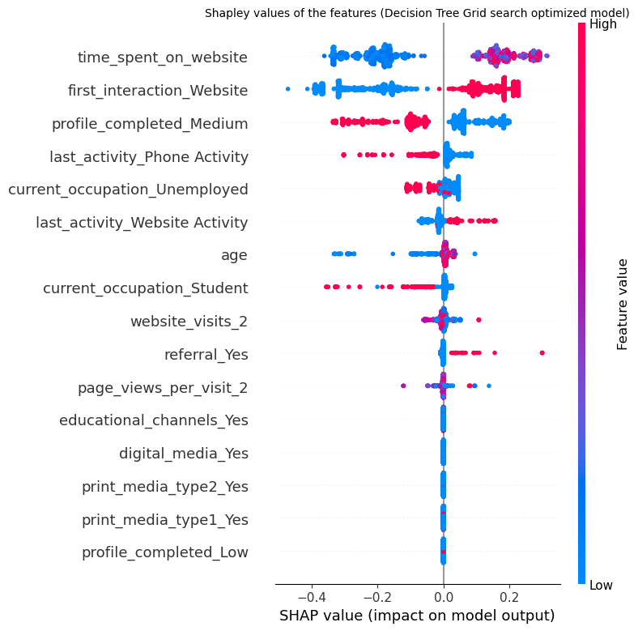

```python
import shap
plt.title('Shapley values of the features (Decision Tree Grid search optimized model)', fontsize=10)
explainer = shap.TreeExplainer(dtree_tuned)
shap_values = explainer.shap_values(X_test)
shap.summary_plot(shap_values[1], X_test)
#shap.plots.beeswarm(shap_values,X_test)
```

[figure not shown]

```python
#Confusion matrix on Test data
from sklearn.metrics import confusion_matrix
cm = confusion_matrix(y_test, y_pred)
plt.figure(figsize=(3,3))
sns.heatmap(data=cm,linewidths=.5, annot=True,  cmap = 'Blues')
plt.ylabel('Actual label')
plt.xlabel('Predicted label')
all_sample_title = 'Accuracy Score for the Tuned Decision Tree on Test data: {0}'.format(dtree_tuned.score(X_test, y_test))
plt.title(all_sample_title, size = 10)
```